# SYSM 6302 - Lab 3

Jonas Wagner, jrw200000

```python
import networkx as nx
import numpy as np
import numpy.linalg as la
import matplotlib.pyplot as plt
import pandas as pd
from IPython.display import Image
```

### Snub Code

This function prints the top five (or `num`) nodes according to the centrality vector `v`, where `v` takes the form: `v[nidx]` is the centrality of the node that is the `nidx`-th element of `G.nodes()`

```python
def print_top_5(G,v, num=5):
    thenodes = list(G.nodes())
    idx_list = [(i,v[i]) for i in range(len(v))]
    idx_list = sorted(idx_list, key = lambda x: x[1], reverse=True)

    for i in range(min(num,len(idx_list))):
        nidx, score = idx_list[i]
        print('  %i. %s (%1.4f)' % (i+1,thenodes[nidx],score))
        #print '  %i. %s' % (i+1,G.node_object(idx))
    return idx_list
```

```python
def index_of_max(v):
    return np.where(v == max(v))[0]
```

This function accepts a dictionary of nodes with centrality values and returns a centrality vector

```python
def centrality_vector(G,d):
    thenodes = list(G.nodes())
    v = np.zeros((G.number_of_nodes(),))
    for i,u in enumerate(thenodes):
        v[i] = d[u]
    return v
```

This function provides the index of a node based on its order in `G.nodes()`

```python
def node_index(G,n):
    thenodes = list(G.nodes())
    return thenodes.index(n)
```

Now we read in the edgelist file that contains the coappearance network we will analyze. We will look at two different networks, corresponding to only the *Lord of the Rings* series and the *Lord of the Rings* series plus the prequel, The *Hobbit*. The `unweighted` boolean, if set to `True` will set all the edge weights to one. Recall that setting all weights to 1 is different (in NetworkX) from having no weights assigned, which could be accomplished instead by: `G = nx.read_edgelist('LoTR_characters.edgelist',data=False)`.

```python
unweighted = True
G = nx.read_weighted_edgelist('LotR_characters.edgelist') # just Lord of the Rings
if unweighted:
    for u,v in G.edges():
        G[u][v]['weight'] = 1
A = nx.adjacency_matrix(G).todense().T
N = G.number_of_nodes()
```

## Section 7.1: Degree Centrality

```python
# Degree Centrality Calculation
v = np.zeros(G.number_of_nodes())
for i,node in enumerate(G.nodes()):
    for edge in list(G[node]):
        v[i] += G[node][edge]['weight']
print('v = ',v)
print('\n')
print('Top 5 Nodes (Degree Centrality)')
print_top_5(G,v)
v_degree_unweighted = v
```

```
v =  [ 78. 140.  88.  80.  47. 124. 144.  65. 102.  63. 125.  90.  71.  71.
  58.  38.  81.  27.  99. 153.  69.  67.  77. 111.  27. 108.  94.  58.
  40.  44.  86.  48.  40.  40.  40.  40.  40.  40.  74. 113.  40.  40.
  91. 137. 110. 104.  40.  53.  50.  51. 105.  66.  40.  31.  64.  45.
  11.  26.  24.  24.  26.  17.  39.  14.  32.  55.  16.  16.  84.   7.
   7.   7.  17.  17.  57.  17.  76.  19.  64.   9.   7.  23.  21.  64.
  79.  52.  68.  61.  21.  24.  62.  24.  24.  24.  24.  24.  62.  54.
  58.  58.  96.  49.  92.  53.  43.  43.  47.  43.  49.  49.  49.  45.
  20.  31.  11.  25.  13.  16.  16.  21.  18.  11.  23.  18.  28.  24.
  22.  22.  13.  38.  20.  18.  24.  12.  24.  20.  20.   6.  23.  11.
  18.  18.  28.  22.  22.  28.  37.  22.  22.  20.  30.  31.  22.   8.
  26.   8.  21.  21.  21.  17.  12.  15.  15.]


Top 5 Nodes (Degree Centrality)
  1. gandalf (153.0000)
  2. frodo (144.0000)
  3. aragorn (140.0000)
  4. pippin (137.0000)
  5. elrond (125.0000)
```

## Section 7.2: Eigenvector Centrality

```python
print('Eigenvector Centrality (by NetworkX):')
v_nx = centrality_vector(G,nx.eigenvector_centrality(G))
eig_un = print_top_5(G,v_nx)
v_eig_unweighted = v_nx
```

```
Eigenvector Centrality (by NetworkX):
  1. gandalf (0.1682)
  2. aragorn (0.1641)
  3. frodo (0.1618)
  4. elrond (0.1541)
  5. pippin (0.1533)
```

```python
print('Eigenvector Centrality (by linear algebra):')
k, V = la.eig(A)
k1_idx = index_of_max(k) # find the index of the largest eigenvalue
v = np.abs(V[:,k1_idx])
deg_un = print_top_5(G,v)
```

```
Eigenvector Centrality (by linear algebra):
  1. gandalf (0.1682)
  2. aragorn (0.1641)
  3. frodo (0.1618)
  4. elrond (0.1541)
  5. pippin (0.1533)
```

#### Calc Confirmation

```python
noi = 'arwen'
noi_idx = node_index(G,noi)

# print('\n Neighbors:')
cent_sum = 0
for node in G.neighbors(noi):
    idx = node_index(G,node)
#     print(node, '%f' % v[idx])
    cent_sum += v[idx] / np.real(k[k1_idx])

print('Confirming that eigenvector centrality is a steady-state of sorts for node %s:' % noi)
print('Eig %f' % v[noi_idx])
print('Sum %f' % cent_sum)
# compare the eigenvector centrality of arwen to the sum of the centralities of its neighbors (divided by the largest eigenvalue)
```

```
Confirming that eigenvector centrality is a steady-state of sorts for node arwen:
Eig 0.112654
Sum 0.112654
```

#### Convergence of Eigenvector Centrality

```
Showing the convergece of eigenvector centrality...
```

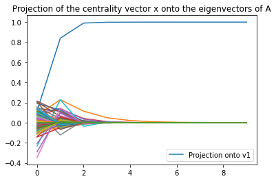

```python
print('Showing the convergece of eigenvector centrality...')
num_steps = 10
x = np.zeros((N,1)) # initial centrality vector
x[76] = 1
cs = np.zeros((N,num_steps))
v = V
for i in range(num_steps):
    x = x/la.norm(x) # at each step we need to normalize the centrality vector
    for j in range(G.number_of_nodes()):
        cs[j,i] = np.real(np.dot( x.T , v[:,j] ))[0] # project x onto each of the eigenvectors
    x = np.dot(A,x) # "pass" the centrality one step forward

plt.figure() # this creates a figure to plot in
for i in range(G.number_of_nodes()): # for each eigenvector plot the projection of x onto it over the steps
    if i == k1_idx:
        plt.plot(range(num_steps),cs[i,:],label='Projection onto v1') # only label the eigenvector v1
    else:
        plt.plot(range(num_steps),cs[i,:])
#plt.ylim([-0.2,1.1]) # this sets the limits for the y axis
plt.legend(loc='best') # this attaches a legend
plt.title('Projection of the centrality vector x onto the eigenvectors of A') # this adds a title
plt.show() # this makes the figure appear
```

In this plot the dot product between the propogated state x (guessed centrality) and the calculated (and correctly known) eigenvalue centrality. As each iteration pases the guessed centrality aligns with v1 (aproches abs(x) * abs(v1)) and becomes orthogonal with all other potential eigenvectors (aproches zero).

The iterative process itself is propogating the guessed centrality through the network (with A) and ultimently is approaching the steady-state centrality vector.

## Section 7.3: Katz Centrality

```python
def katz(A, alpha = 0.85, beta = 1):
    n = np.size(A,1)
    # Asumming beta are scalers (same for all nodes... at least for defualt)
    old = np.array(np.linalg.inv(np.eye(np.size(A,1)) - np.dot(alpha,A)).dot(beta * np.ones(np.size(A,1)))).flatten()
    new = beta * np.linalg.inv(np.eye(n) - alpha * A) @ (np.ones((n,1)))
    v_nx = centrality_vector(G,nx.katz_centrality_numpy(G,alpha,beta))
    return v_nx
```

```python
Alpha = [0.1,0.25,0.5,0.75,0.9]
for alpha in Alpha:
    v_katz = katz(A,alpha)
    print('Katz Centrality (alpha = %f):' % alpha)
    print_top_5(G,v_katz)
    print('\n')
v_katz_unweighted = katz(A)
# katz_un = print_top_5(G,v_katz_unweighted)
```

```
Katz Centrality (alpha = 0.100000):
  1. galadriel (0.1523)
  2. gimli (0.1385)
  3. arathorn (0.1211)
  4. legolas (0.1113)
  5. halbarad (0.1036)


Katz Centrality (alpha = 0.250000):
  1. bilbo (0.2356)
  2. dunhere (0.2067)
  3. frodo (0.2025)
  4. fundin (0.1754)
  5. gandalf (0.1736)


Katz Centrality (alpha = 0.500000):
  1. hammerhand (0.1958)
  2. angbor (0.1950)
  3. aragorn (0.1594)
  4. theoden (0.1431)
  5. varda (0.1329)


Katz Centrality (alpha = 0.750000):
  1. eothain (0.3417)
  2. theoden (0.2415)
  3. anborn (0.1854)
  4. rumil (0.1808)
  5. celeborn (0.1694)


Katz Centrality (alpha = 0.900000):
  1. frar (0.3656)
  2. smeagol (0.1873)
  3. eowyn (0.1734)
  4. arvedui (0.1722)
  5. oin (0.1653)
```

## PageRank

```python
def pageRank(A, alpha = 0.85, beta = 1):
    # Asumming beta are scalers (same for all nodes... at least for defualt)
    D = np.diag(np.array(np.sum(A,0)).flatten())
    return np.array(np.dot(np.linalg.inv(np.eye(np.size(A,1))
                                         - np.dot(np.dot(alpha,A),
                                                  np.linalg.inv(D))),
                           beta * np.ones(np.size(A,1)))).flatten()
```

```python
alpha = 0.85
v_PR = pageRank(A,alpha)
print('Page Rank (alpha = %f):' % alpha)
pr_un = print_top_5(G,v_PR)
v_PR_unweighted = v_PR
```

```
Page Rank (alpha = 0.850000):
  1. gandalf (22.1478)
  2. frodo (20.9287)
  3. pippin (19.7588)
  4. aragorn (19.4926)
  5. bilbo (17.7511)
```

#### PageRank proof

$A$ is given as the adjacency matrix of a directed network, Let $$v_1 = [k_1,k_2,...,k_n]^T, \ \ k_i = k_i^{in}$$ be the vector of the degrees of the nodes.\ Similarily, let $$D = \diag[k_1,k_2,\dots,k_n]$$, be representative of the degrees along each node (but also ensure that any zero $k_i$ terms are set to 1).\ From degree centrality we know that $AD^{-1}$ itself charectorizes the degree centrality and thus we know that by $$A D^{-1} x = \lambda_i x$$ the primary (1st SVD) eigenvector is $v$.\ Looking at the definition of Page Rank, $$x = (I - \alpha A D^{-1})^{-1},$$ it is know posible to say that when $\alpha = 1$ the quantity $I - \alpha AD^{-1}$ becomes singular, causing the inverse to be undefined. Therefore we can conclude that $\alpha \in [0,1)$.

## Section 7.5: Hubs & Authorities

The authority centrality of a node is proportional to the sum of the hub centralities one nodes that point to it: $$x_i = \alpha \sum_j A_{ij} y_j$$ Similarily the hub centrality of a node is a sum of the authority centralities of nodes it points to: $$y_j = \beta \sum_i A_{ij} x_i$$ This can be written in matrix form as: $$x = \alpha A y$$ and $$ y = \beta A x$$ once they are combined and restructured to form the following: $$AA^T x = \lambda x$$ and $$A^TAy = \lambda y$$ with $\lambda = (\alpha \beta)^{-1}$. Since both share the same eigenvalues $A$ and $A^T$ are commutable, so: $$A^A(A^Tx) = \lambda (A^Tx)$$ which with another substitution becomes: $$y=A^T x$$

## Section 7.7: Betweenness Centrality

```python
G_unweighted = G
```

```python
print('Betweeness Centrality (by NetworkX):')
v = centrality_vector(G,nx.betweenness_centrality(G))
btw_un = print_top_5(G,v)
v_between_unweighted = v
```

```
Betweeness Centrality (by NetworkX):
  1. gandalf (0.0797)
  2. frodo (0.0675)
  3. pippin (0.0613)
  4. aragorn (0.0486)
  5. bilbo (0.0393)
```

## Weighted Analysis

```python
G = nx.read_weighted_edgelist('LotR_characters.edgelist') # just Lord of the Rings
A = nx.adjacency_matrix(G).todense().T
N = G.number_of_nodes()
```

#### Degree Centrality Comparrision

```python
print('Top 5 Nodes (Degree Centrality) - Unweighted')
print_top_5(G_unweighted,v_degree_unweighted);
```

```
Top 5 Nodes (Degree Centrality) - Unweighted
  1. gandalf (153.0000)
  2. frodo (144.0000)
  3. aragorn (140.0000)
  4. pippin (137.0000)
  5. elrond (125.0000)
```

```python
# Degree Centrality Calculation
v = np.zeros(G.number_of_nodes())
for i,node in enumerate(G.nodes()):
    for edge in list(G[node]):
        v[i] += G[node][edge]['weight']
print('Top 5 Nodes (Degree Centrality) - Weighted')
deg_w = print_top_5(G,v)
v_degree_weighted = v
```

```
Top 5 Nodes (Degree Centrality) - Weighted
  1. gandalf (762.0000)
  2. frodo (661.0000)
  3. aragorn (632.0000)
  4. pippin (606.0000)
  5. elrond (484.0000)
```

Degree centrality remained pretty much the same as order is concerned. Obviously the values increased but that is to be expected.

#### Eigenvector Centrality

```python
print('Eigenvector Centrality - Unweighted')
print_top_5(G_unweighted,v_eig_unweighted);
```

```
Eigenvector Centrality - Unweighted
  1. gandalf (0.1682)
  2. aragorn (0.1641)
  3. frodo (0.1618)
  4. elrond (0.1541)
  5. pippin (0.1533)
```

```python
print('Eignevector Centrality - Weighted')
v = centrality_vector(G,nx.eigenvector_centrality(G))
eig_w = print_top_5(G,v)
v_eig_weighted = v
```

```
Eignevector Centrality - Weighted
  1. gandalf (0.1682)
  2. aragorn (0.1641)
  3. frodo (0.1618)
  4. elrond (0.1541)
  5. pippin (0.1533)
```

Eigenvector centrality remained basically the same.

#### Katz Centrality

```python
print('Katz Centrality - Unweighted')
print_top_5(G_unweighted,v_katz_unweighted);
```

```
Katz Centrality - Unweighted
  1. hammerhand (0.2842)
  2. finrod (0.2516)
  3. celeborn (0.2416)
  4. frar (0.1839)
  5. goldberry (0.1711)
```

```python
print('Katz Centrality - Weighted')
v = katz(A)
katz_w = print_top_5(G,v)
v_katz_weighted = v
```

```
Katz Centrality - Weighted
  1. hammerhand (0.2842)
  2. finrod (0.2516)
  3. celeborn (0.2416)
  4. frar (0.1839)
  5. goldberry (0.1711)
```

#### Page Rank

```python
print('Page Rank Centrality - Unweighted')
print_top_5(G_unweighted,v_PR_unweighted);
```

```
Page Rank Centrality - Unweighted
  1. gandalf (22.1478)
  2. frodo (20.9287)
  3. pippin (19.7588)
  4. aragorn (19.4926)
  5. bilbo (17.7511)
```

```python
alpha = 0.85
v_PR = pageRank(A,alpha)
print('Page Rank (alpha = %f):' % alpha)
pr_w = print_top_5(G,v_PR)
v_PR_unweighted = v_PR
```

```
Page Rank (alpha = 0.850000):
  1. gandalf (44.3470)
  2. frodo (39.4107)
  3. aragorn (36.0736)
  4. pippin (35.6541)
  5. elrond (28.1555)
```

#### Betweeness Centrality

```python
print('Betweeness Centrality - Unweighted')
print_top_5(G_unweighted,v_between_unweighted);
```

```
Betweeness Centrality - Unweighted
  1. gandalf (0.0797)
  2. frodo (0.0675)
  3. pippin (0.0613)
  4. aragorn (0.0486)
  5. bilbo (0.0393)
```

```python
print('Betweeness Centrality - Weighted')
v = centrality_vector(G,nx.betweenness_centrality(G))
btw_w = print_top_5(G,v)
v_between_weighted = v
```

```
Betweeness Centrality - Weighted
  1. gandalf (0.0797)
  2. frodo (0.0675)
  3. pippin (0.0613)
  4. aragorn (0.0486)
  5. bilbo (0.0393)
```

## A Sequel (Prequel - The Hobbit)

```python
G_weighted = G
```

```python
G = nx.read_weighted_edgelist('hobbit_LotR_characters.edgelist') # with the Hobbit
A = nx.adjacency_matrix(G).todense().T
N = G.number_of_nodes()
```

```python
# Degree Centrality Calculation
v = np.zeros(G.number_of_nodes())
for i,node in enumerate(G.nodes()):
    for edge in list(G[node]):
        v[i] += G[node][edge]['weight']
print('Top 5 Nodes (Degree Centrality) - Hobbit')
deg_h = print_top_5(G,v)
v_deg_hobbit = v
```

```
Top 5 Nodes (Degree Centrality) - Hobbit
  1. gandalf (901.0000)
  2. frodo (661.0000)
  3. aragorn (632.0000)
  4. pippin (606.0000)
  5. bilbo (602.0000)
```

#### Eigenvector Centrality

```python
print('Eignevector Centrality - Hobbit')
v = centrality_vector(G,nx.eigenvector_centrality(G))
eig_h = print_top_5(G,v)
v_eig_hobbit = v
```

```
Eignevector Centrality - Hobbit
  1. gandalf (0.1692)
  2. aragorn (0.1618)
  3. frodo (0.1598)
  4. elrond (0.1534)
  5. bilbo (0.1531)
```

#### Katz Centrality

```python
print('Katz Centrality - Hobbit')
v = katz(A)
katz_h = print_top_5(G,v)
v_katz_hobbit = v
```

```
Katz Centrality - Hobbit
  1. theoden (0.2725)
  2. hammerhand (0.2584)
  3. eothain (0.2499)
  4. brand (0.2494)
  5. hamfast (0.1465)
```

Honestly the Katz centrality was just all over the place for me... didn't work well at all... but looking at the results it appears to greatly change.

#### Page Rank

```python
alpha = 0.85
v_PR = pageRank(A,alpha)
print('Page Rank (alpha = %f):' % alpha)
pr_h = print_top_5(G,v_PR)
v_PR_unweighted = v_PR
```

```
Page Rank (alpha = 0.850000):
  1. gandalf (48.7526)
  2. frodo (36.8473)
  3. aragorn (33.6945)
  4. pippin (33.3878)
  5. bilbo (33.2073)
```

#### Betweeness Centrality

```python
print('Betweeness Centrality - Hobbit')
v = centrality_vector(G,nx.betweenness_centrality(G))
btw_h = print_top_5(G,v)
v_between_hobbit = v
```

```
Betweeness Centrality - Hobbit
  1. gandalf (0.1042)
  2. frodo (0.0588)
  3. bilbo (0.0563)
  4. pippin (0.0541)
  5. aragorn (0.0426)
```

## Results

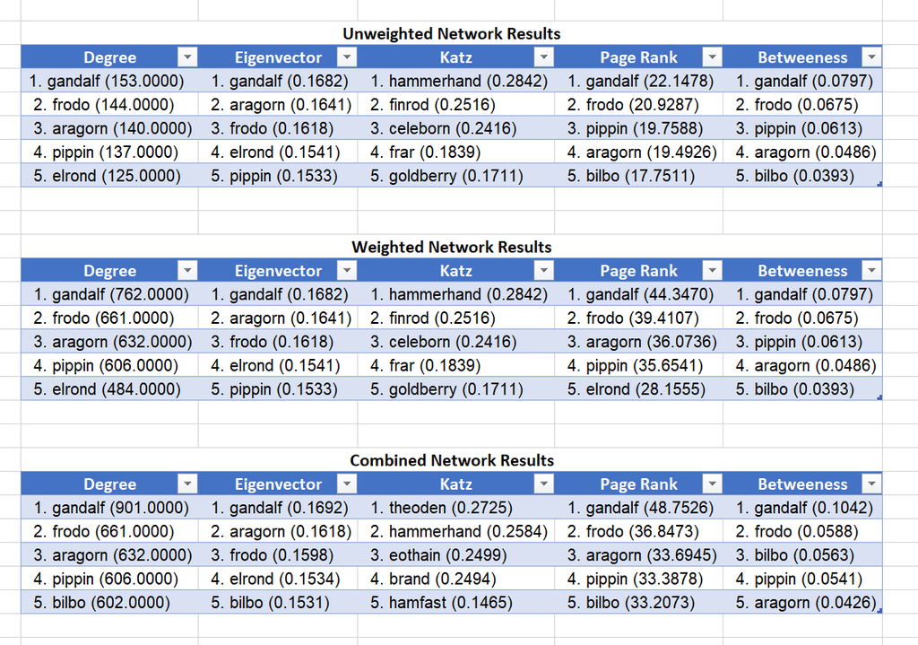

```python
Image(filename='fig/finaldata.png')
```